# ANLY 545_50 HW_4

Mahesh

December 17, 2018

## Exercise 5.1

**The data set criminal in the package logmult gives the 4 × 5 table below of the number of men aged 15-19 charged with a criminal case for whom charges were dropped in Denmark from 1955-1958.**

**a. Use loglm() to test whether there is an association between Year and Age. Is there evidence that dropping of charges in relation to age changed over the years recorded here?**

```r
library(MASS)
data("criminal", package = "logmult")
criminal
```

```
##       Age
## Year    15  16  17  18  19
##   1955 141 285 320 441 427
##   1956 144 292 342 441 396
##   1957 196 380 424 462 427
##   1958 212 424 399 442 430
```

```r
loglm(~Year + Age, data = criminal)
```

```
## Call:
## loglm(formula = ~Year + Age, data = criminal)
##
## Statistics:
##                       X^2 df     P(> X^2)
## Likelihood Ratio 38.24466 12 0.0001400372
## Pearson          38.41033 12 0.0001315495
```

Since p value is < 0.05, there is some association between **Year** and **Age**.

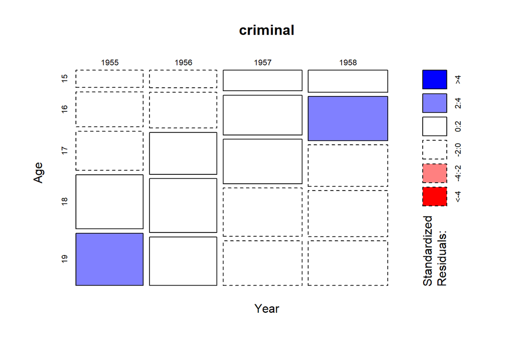

```r
plot(criminal, shade = TRUE)
```

The higher the year, younger people are in higher frequency bucket and vice-versa.

**b. Use mosaic() with the option shade=TRUE to display the pattern of signs and magnitudes of the residuals. Compare this with the result of mosaic() using “Friendly shading,” from the option gp=shading_Friendly. Describe verbally what you see in each regarding the pattern of association in this table.**

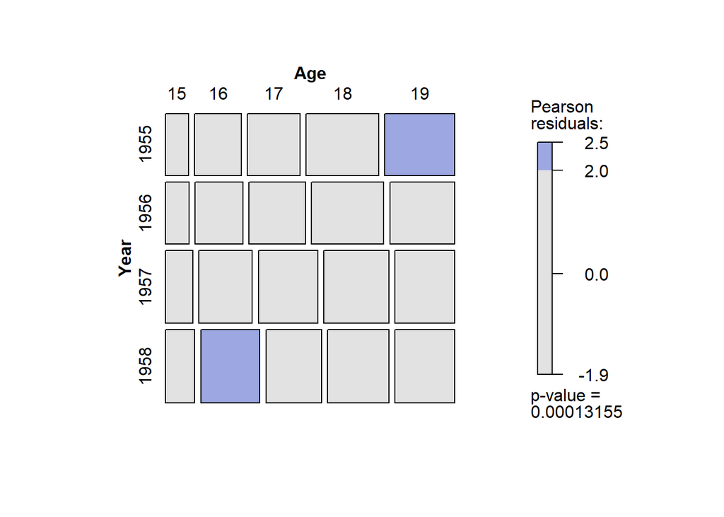

```r
library(vcd)
mosaic(criminal, shade = TRUE)
```

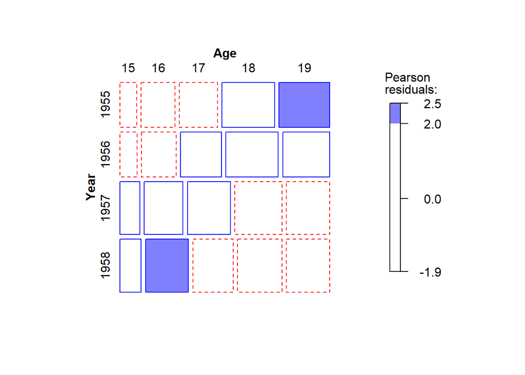

```r
mosaic(criminal, gp=shading_Friendly)
```

The two plots are shaded differently to reflect difference in residual based shadings. Positive residuals are shaded with blue outline for better visualization in the second plot.

## Exercise 5.9

**Bertin (1983, pp. 30-31) used a 4-way table of frequencies of traffic accident victims in France in 1958 to illustrate his scheme for classifying data sets by numerous variables, each of which could have various types and could be assigned to various visual attributes. His data are contained in Accident in vcdExtra, a frequency data frame representing his 5 × 2 × 4 × 2 table of the variables age, result (died or injured), mode of transportation, and gender.**

**a. Use loglm() to fit the model of mutual independence, Freq ~ age+mode+gender+result to this data set.**

```r
data("Accident", package = "vcdExtra")

loglm(Freq ~ age+mode+gender+result, data = Accident)
```

```
## Call:
## loglm(formula = Freq ~ age + mode + gender + result, data = Accident)
##
## Statistics:
##                       X^2 df P(> X^2)
## Likelihood Ratio 60320.05 70        0
## Pearson          76865.31 70        0
```

**b. Use mosaic() to produce an interpretable mosaic plot of the associations among all variables under the model of mutual independence. Try different orders of the variables in the mosaic. (Hint: the abbreviate component of the labeling_args argument to mosaic() will be useful to avoid some overlap of the category labels.)**

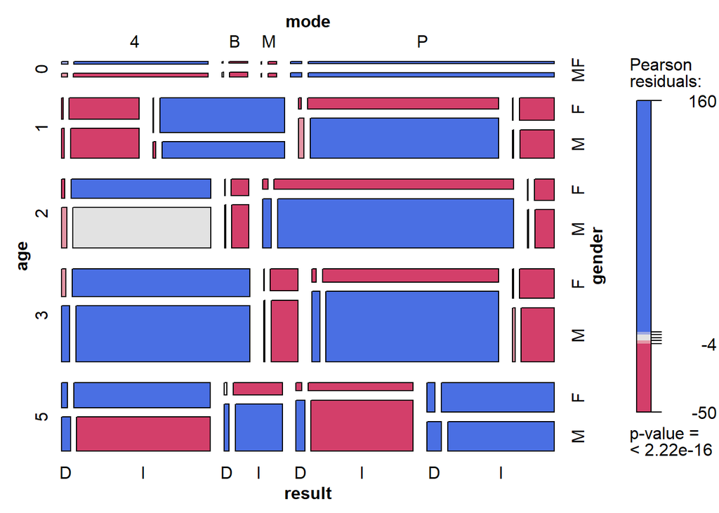

```r
mosaic(Freq ~ age + mode + gender + result, data = Accident, shade = TRUE, labeling_args = list(abbreviate_labs=TRUE))
```

**c. Treat result (“Died” vs. “Injured”) as the response variable, and fit the model Freq ~ age*mode*gender + result that asserts independence of result from all others jointly.**

```r
loglm(Freq ~ age*mode*gender+result, data=Accident)
```

```
## Call:
## loglm(formula = Freq ~ age * mode * gender + result, data = Accident)
##
## Statistics:
##                      X^2 df P(> X^2)
## Likelihood Ratio 2217.72 39        0
## Pearson          2347.60 39        0
```

**d. Construct a mosaic display for the residual associations in this model. Which combinations of the predictor factors are more likely to result in death?**

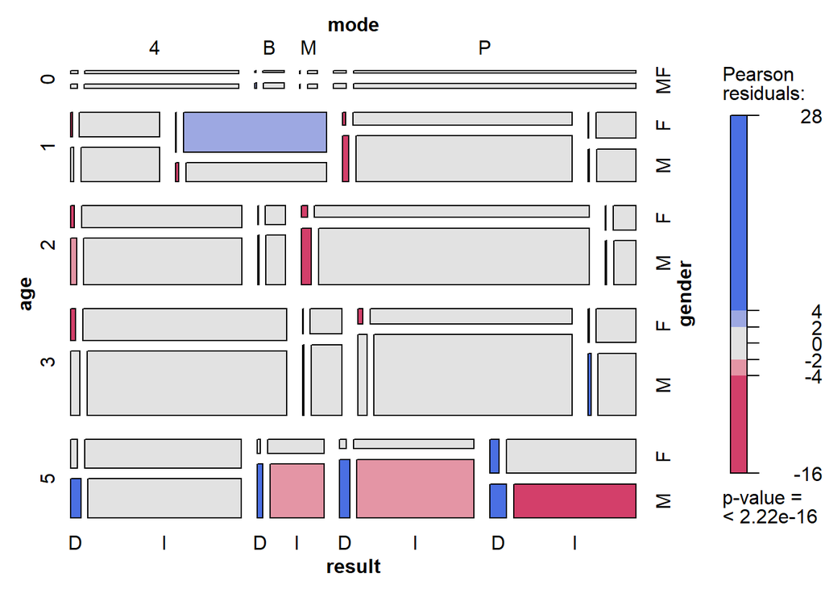

```r
mosaic(loglm(Freq ~ age*mode*gender+result, data=Accident),shade = TRUE, labeling_args = list(abbreviate_labs=TRUE))
```

**.** For males, mode of accident as Motorcycle and age of 50+ are more likely to die.

**.** It is then followed by Bicycle accidents and age 50+.

**.** For females, more frequent causes of death are among pedesterians with ages 50+.

**.** Lowest deaths are certainly in the lower age basket of 0-9.